# Unit 4 Lesson 2 PCHiC integration with epigenomics

Csilla Varnai

2022-08-19

You will be working with processed chromatin contact and epigenomics data for Macrophages by Javierre et al. In this activity, you will identify if active promoters are enriched in interactions with active enhancers, where chromatin activity is determined using the epigenomics data.

## 1. Input files and data processing

First, let us read the input data, and interpret what is stored in each column. The columns of the file contain the following information:

The chromatin activity status for the regulatory features was determined by Javierre et al. using the Chrom-HMM software (). It can take the values:

- 0: dead, no signal,
- 1: active, open chromatin (ATAC-seq peak) or active marks (active histone modification peak),
- 2: poised, containing bivalent marks, i.e. both active and repressive chromatin marks,
- 3: Polycomb-repressed, with a H3K27me3 histone modification mark,
- 4: NA, cell-type independent regulatory features, e.g. transcription factor binding sites or CTCF bindin sites.

```r
#interactions_all = as.data.frame(read.table("RegBuild_BLUEPRINT_annotations_all_valid_chromatin_status.txt", header = TRUE, sep = " "))
#head(interactions_all)
#write.table(filter(interactions_all, CellType=="Mac0")[,c(1:16,21)],"RegBuild_BLUEPRINT_annotations_Mac0_with_fragment_activity_scores.txt",
#            row.names = FALSE, col.names = TRUE, sep = "\t", quote = FALSE, append = FALSE)
interactions = as.data.frame(read.table("RegBuild_BLUEPRINT_annotations_Mac0_with_fragment_activity_scores.txt", header = TRUE, sep = "\t"))
head(interactions)
```

```
##   BaitID BaitChr BaitStart BaitEnd OtherEndID OtherEndChr OtherEndStart
## 1    250       1   1126526 1150969        219           1        848169
## 2    218       1    831895  848168        220           1        850619
## 3    250       1   1126526 1150969        220           1        850619
## 4    255       1   1212439 1220554        220           1        850619
## 5    228       1    943677  957199        224           1        903641
## 6    234       1   1005127 1034268        224           1        903641
##   OtherEndEnd  DonorID CellType SignifInteraction
## 1      850618 S00390H1     Mac0                 1
## 2      874081 S00390H1     Mac0                 1
## 3      874081 S00390H1     Mac0                 1
## 4      874081 S00390H1     Mac0                 1
## 5      927394 S00390H1     Mac0                 1
## 6      927394 S00390H1     Mac0                 1
##                                                                                   BaitRegFeatIDs
```

[output cut: 27 more lines]

Count the number of significant interactions and save it in a variable **n_total**.

```r
#n_total = # write your code here
n_total = nrow(interactions)
n_total
```

```
## [1] 51547
```

Count the number and fraction of interactions involving an active promoter containing fragment.

```r
#p_BaitActive = # write your code here
p_BaitActive = sum(interactions$BaitActive) / nrow(interactions)
p_BaitActive
```

```
## [1] 0.7156576
```

Count the number and fraction of interactions involving an active “other end” fragment.

```r
#p_OtherEndActive = # write your code here
p_OtherEndActive = sum(interactions$OtherEndActive) / nrow(interactions)
p_OtherEndActive
```

```
## [1] 0.05546395
```

# 2. Enrichment of interactions

We will compute the matrix of interaction enrichment between active/inactive promoters and active/inactive enhancers. The enrichment of interactions is the 2-based logarithm of the ratio of observed and expected number of interactions.

Let us first initialise the enrichment matrix.

```r
  enrichment_matrix = matrix(data = NA, nrow = 2, ncol = 2)
  rownames(enrichment_matrix) = c("active_promoter", "inactive_promoter")
  colnames(enrichment_matrix) = c("active_enhancer", "inactive_enhancer")
```

Now let us compute the individual elements of the matrix. The observed number of interactions is a simple count. To compute the expected number of interactions, we assume that selecting an active promoter or an active enhancer is independent. Hence, the joint probability is the product of the individual probabilities. We also use the fact that the sum of probabilities of picking an active or an inactive “other end” is 1. As such, the enrichment of interactions between active promoter containing fragments and inactive enhancer containing fragments can be computed using the following command:

```r
  enrichment_matrix[1,2] = log2( sum(interactions$BaitActive & !interactions$OtherEndActive) / ( p_BaitActive * (1-p_OtherEndActive) * n_total ) )
enrichment_matrix
```

```
##                   active_enhancer inactive_enhancer
## active_promoter                NA       -0.01167912
## inactive_promoter              NA                NA
```

Now compute the other three elements of the enrichment matrix.

```r
# write your code here
enrichment_matrix[1,1] = log2( sum(interactions$BaitActive & interactions$OtherEndActive) / ( p_BaitActive * p_OtherEndActive * n_total ) )
enrichment_matrix[2,1] = log2( sum(!interactions$BaitActive & interactions$OtherEndActive) / ( (1-p_BaitActive) * p_OtherEndActive * n_total ) )
enrichment_matrix[2,2] = log2( sum(!interactions$BaitActive & !interactions$OtherEndActive) / ( (1-p_BaitActive) * (1-p_OtherEndActive) * n_total ) )
enrichment_matrix
```

```
##                   active_enhancer inactive_enhancer
## active_promoter         0.1856193       -0.01167912
## inactive_promoter      -0.6117138        0.02898325
```

Now let’s plot the enrichment matrix, using the **heatmap.2()** function of the **gplots** library. Look up the help page of the **heatmap.2()** function, to interpret the plot command.

```r
?heatmap.2()
```

Plot the enrichment matrix, with a custom blue-white-red palette centred on 0 which represents no enrichment.

[figure not shown]

```r
palette3 <- colorRampPalette(c("blue","white","red"),space="rgb")(256)
heatmap.2(enrichment_matrix,Rowv=NA, Colv=NA,
          dendrogram = "none", scale='none',trace='none',symkey=T, breaks=seq(-0.5,0.5,length.out=257),col=palette3,
          sub="", xlab = "promoter", labRow = c("active","inactive"), cexRow = 1,
          ylab = "enhancer", labCol = c("active","inactive"), cexCol = 1,
          cellnote = round(enrichment_matrix, 3), notecol = "black", notecex = 2,
          density.info = "none", key.title = "enrichment", key.xlab = "log2(Obs/Exp)", key.ylab = "")
```

Save in a file.

```r
pdf("Mac0_enrichment.pdf", width = 7, height = 7)
palette3 <- colorRampPalette(c("blue","white","red"),space="rgb")(256)
heatmap.2(enrichment_matrix,Rowv=NA, Colv=NA,
          dendrogram = "none", scale='none',trace='none',symkey=T, breaks=seq(-0.5,0.5,length.out=257),col=palette3,
          sub="", xlab = "promoter", labRow = c("active","inactive"), cexRow = 1,
          ylab = "enhancer", labCol = c("active","inactive"), cexCol = 1,
          cellnote = round(enrichment_matrix, 2), notecol = "black", notecex = 2,
          density.info = "none", key.title = "enrichment", key.xlab = "log2(Obs/Exp)", key.ylab = "")
dev.off()
```

# 3. Identify the significance level of enrichment

We will now identify the significance levels of enrichment between active promoters and active enhancers.

To do this, we will do a permutation test to determine the expected distribution of the enrichment in a shuffled data. By comparing the observed enrichment to the distribution, and computing what proportion of the expected distribution is higher than the observed enrichment, we get the probability that our enrichment is higher than randomly occurring enrichment scores.

```r
em_perm = array(NA, dim = 10000)
for (i in 1:10000) {
  shuffled_data <- interactions %>% mutate(BaitActive = sample(BaitActive, replace = FALSE)) %>% mutate(OtherEndActive = sample(OtherEndActive, replace = FALSE))
  # write code here
  em_perm[i] = log2( sum(shuffled_data$BaitActive & shuffled_data$OtherEndActive) / ( p_BaitActive * p_OtherEndActive * n_total ) )
}
```

Now use the **hist()** function to plot the distribution of the enrichments in the shuffled data, with the P=0.05 significance level marked.

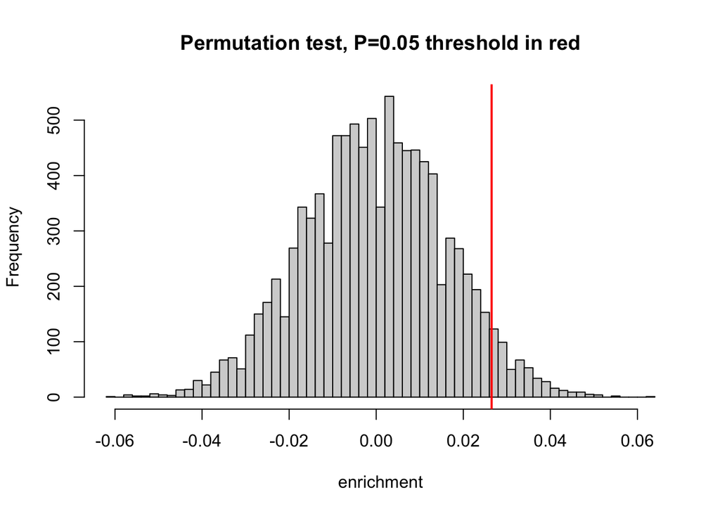

```r
hist(em_perm, breaks = 50, xlab = "enrichment", main = "Permutation test, P=0.05 threshold in red")
abline(v = quantile(em_perm, probs = 0.95), col = 'red', lwd = 2)
```

Identify is the observed enrichment is significant using a P=0.05 significance threshold.

```r
# write your code here
enrichment_matrix[1,1] > quantile(em_perm, probs = 0.95)
```

```
##  95%
## TRUE
```